# ggplot и начало тестов

Гупаисова Яна 21.Б02-с

2023-10-21

# Данные

Для начала загрузим данные и подготовим их.

```r
#загружаем данные
fuel <- read.csv("C:/Users/Yana/Documents/vehicles.csv")

#перекодируем переменную trany
fuel$trany[fuel$trany==""] <- NA
fuel$trany2 <- ifelse(substr(fuel$trany,1,1)=="A", "Automatic", "Manual")
fuel$trany2 <- as.factor(fuel$trany2)
```

# Так-с: 1

Создадим дихотомическую переменную, которая будет отвечать за тип бензина. 1 - бензиновый (gasoline), 0 - любой другой.

```r
library(stringr)
fuel$gasoline <- ifelse((str_detect(fuel$fuelType1, "Gasoline")&(fuel$fuelType2 == "")&(fuel$atvType != "Hybrid")), 1, 0)
```

Теперь найдем самые экономичные и неэкономичные модели автомобилей по переменной comb08 среди тех, которые ездят на бензине и занесем их в список.

```r
gasoline_fuel <- fuel[fuel$gasoline==1,]
list <- c(head(gasoline_fuel[order(gasoline_fuel$comb08),c("make","model","year","comb08")],5),tail(gasoline_fuel[order(gasoline_fuel$comb08),c("make","model","year","comb08")],5))
print(list)
```

```
## $make
## [1] "Lamborghini" "Lamborghini" "Lamborghini" "Lamborghini" "Lamborghini"
##
## $model
## [1] "Countach" "Countach" "Countach" "Countach" "Countach"
##
## $year
## [1] 1986 1987 1988 1989 1990
##
## $comb08
## [1] 7 7 7 7 7
##
## $make
## [1] "Geo"       "Geo"       "Geo"       "Geo"       "Chevrolet"
##
## $model
## [1] "Metro XFI" "Metro XFI" "Metro XFI" "Metro XFI" "Sprint ER"
##
## $year
## [1] 1990 1991 1992 1993 1986
##
## $comb08
## [1] 47 47 47 47 48
```

**Видим, что самые прожорливые машины - это Countach, их несколько лет подряд выпускал Lamborghini, и они могут проехать только 7 миль на одном галлоне. Самый экономичный автомобиль был выпущен в 1986 год, он мог проехать 48 миль на одном галлоне - Sprint ER марки Chevrolet. Даже удивительно, что его назвали Спринт.**

# Так-с: 2

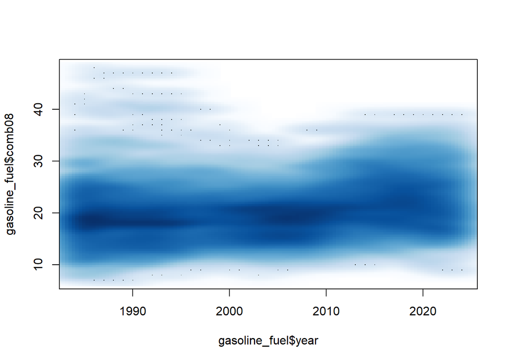

```
## пользователь      система       прошло
##         0.03         0.15         0.19
```

```r
system.time(smoothScatter(gasoline_fuel$year, gasoline_fuel$comb08))
```

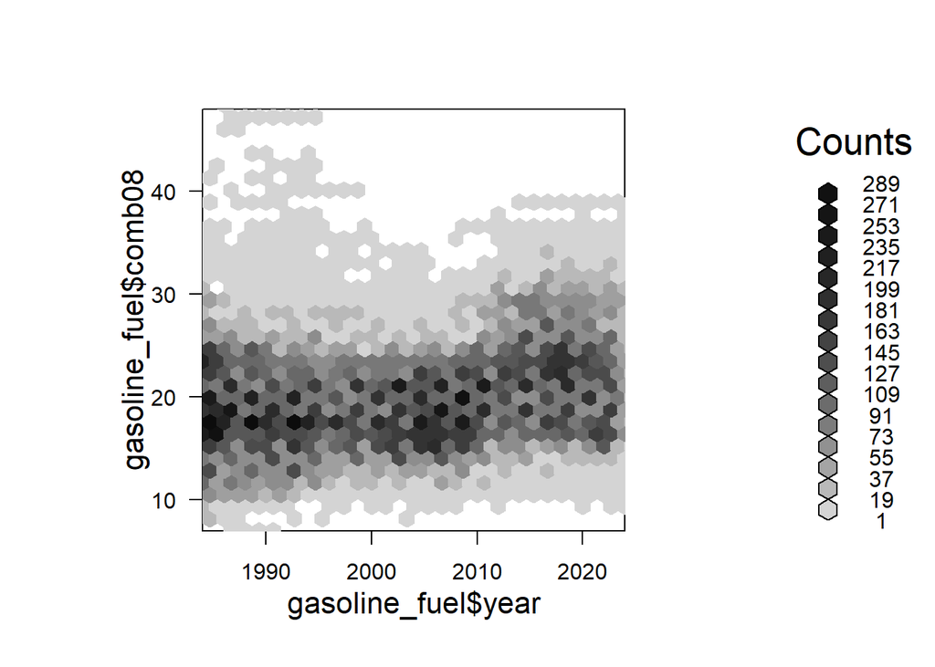

```
## пользователь      система       прошло
##         0.04         0.05         0.10
```

```r
library(hexbin)
system.time(plot(hexbin(gasoline_fuel$year, gasoline_fuel$comb08)))
```

**На мой взгляд, второй вариант практичнее по двум причинам: 1) время - функция hexbin работает в 1,5-2 раза быстрее чем smoothScatter 2) четкость картинки - в случае с hexbin лучше виден контраст, точки легче соотносить со значениями по осям.**

# Так-с: 3

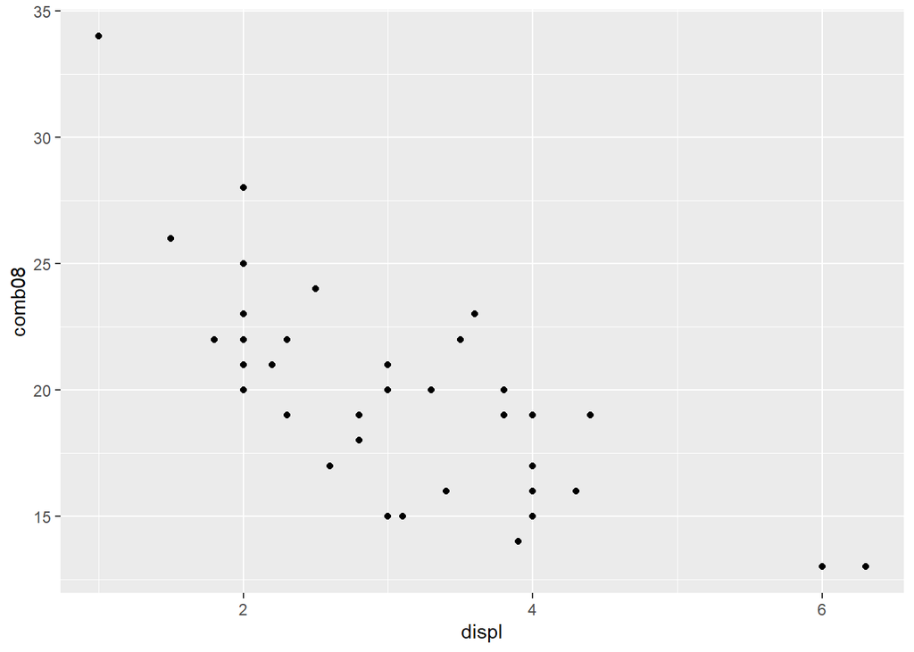

```r
d=gasoline_fuel[sample(1:nrow(gasoline_fuel), 40),]
library(ggplot2)
disp_comb <- ggplot(data = d,
     aes(x = displ, y = comb08)) +
     geom_point()
disp_comb
```

Используем функцию lm, которая построит линию регрессии и функцию geom_abline, которая создаст слой на графике для ее отображения.

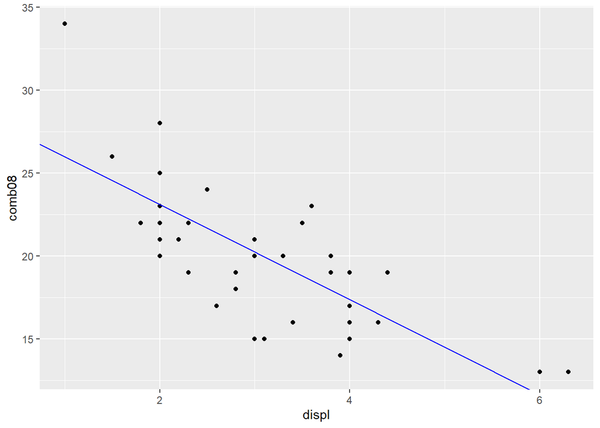

```r
coeff<-coefficients(lm(formula = comb08 ~ displ,data=d))
disp_comb + geom_abline(intercept = coeff[1], slope = coeff[2],
                    color="blue")
```

Теперь воспользуемся функцией stat_smooth.

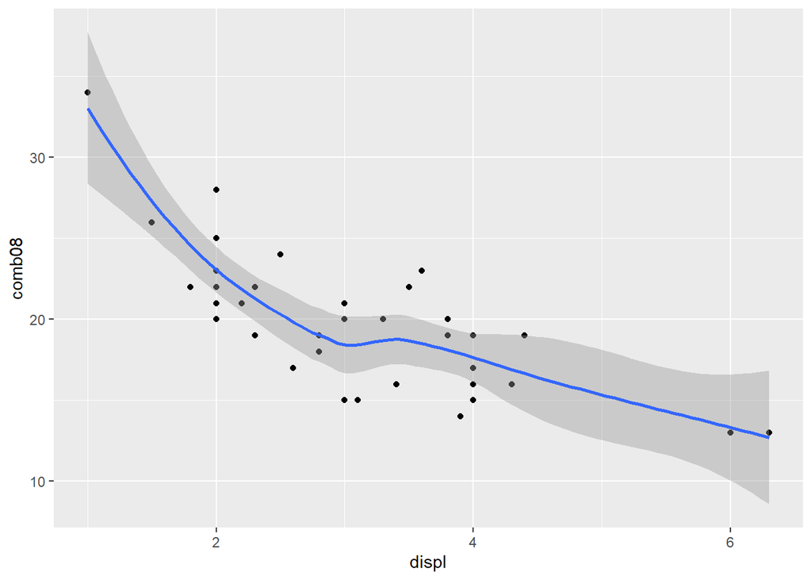

```r
disp_comb + stat_smooth()
```

Придадим функции тип lm, чтобы отражалась прямая линия регрессии.

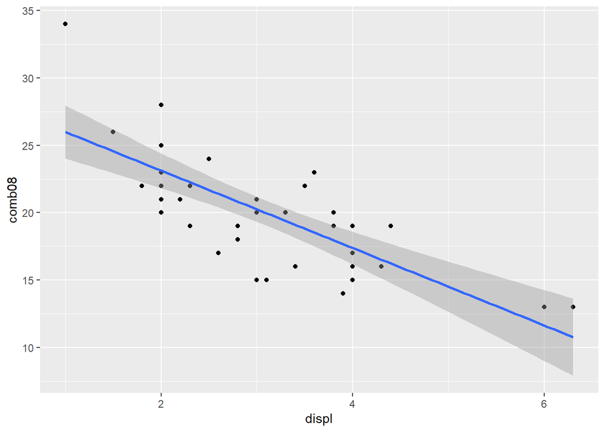

```r
disp_comb + stat_smooth(method = "lm")
```

Видим, что функция stat_smooth, в отличие от geom_abline, показывает разброс значений от линии регрессии.

# Так-с: 4

```r
x1=subset(gasoline_fuel, trany2=='Automatic'& year==2000 , select = comb08)
x2=subset(gasoline_fuel, trany2=='Manual'& year==2000, select = comb08)

(res=t.test(x1,x2))
```

```
##
##  Welch Two Sample t-test
##
## data:  x1 and x2
## t = -7.8001, df = 436.95, p-value = 4.592e-14
## alternative hypothesis: true difference in means is not equal to 0
## 95 percent confidence interval:
##  -3.022015 -1.805591
## sample estimates:
## mean of x mean of y
##  18.38165  20.79545
```

```r
res$statistic
```

```
##         t
## -7.800089
```

```r
res$p.value
```

```
## [1] 4.591557e-14
```

Создадим пустой датафрейм, в который будем вносить данные по t-статистика и значимость по каждому году наблюдения.

```r
t_test <- data.frame(matrix(ncol = 3, nrow = length(c(min(gasoline_fuel$year):max(gasoline_fuel$year)))))
colnames(t_test) <- c("год","t-статистика","значимость")
t_test[,1] <- c(min(gasoline_fuel$year):max(gasoline_fuel$year))
```

Напишем цикл, который будет по каждому году проверять гипотезу об отсутствии или наличии связи между переменной типа трансмиссии (ручной или автомат) и переменной расхода топлива (миль на галлон).

```r
for (i in c(min(gasoline_fuel$year):max(gasoline_fuel$year))) {
  x1=subset(gasoline_fuel, trany2=='Automatic'& year == i , select = comb08)
  x2=subset(gasoline_fuel, trany2=='Manual'& year == i, select = comb08)
  res=t.test(x1,x2)
  t_test[i-min(gasoline_fuel$year)+1,2] <- res$statistic
  t_test[i-min(gasoline_fuel$year)+1,3] <- res$p.value
}
```

Внесем еще один столбец, в котором будем писать вывод: отвергаем мы нулевую гипотезу или принимаем. Нулевая гипотеза - об отсутствии связи между переменными. Уровень значимости - 0.05

```r
t_test$нулевая_гипотеза <- ifelse(t_test$значимость >= 0.05, "принимаем","отвергаем")
print(head(t_test))
```

```
##    год t-статистика   значимость нулевая_гипотеза
## 1 1984   -14.884483 7.108145e-47        отвергаем
## 2 1985   -12.127364 3.832044e-32        отвергаем
## 3 1986    -9.233972 1.603953e-19        отвергаем
## 4 1987    -9.545928 9.096276e-21        отвергаем
## 5 1988    -7.586372 8.007669e-14        отвергаем
## 6 1989    -6.969123 6.108140e-12        отвергаем
```

```r
print(tail(t_test))
```

```
##     год t-статистика   значимость нулевая_гипотеза
## 36 2019   -4.0086099 8.719914e-05        отвергаем
## 37 2020   -2.9617355 3.695084e-03        отвергаем
## 38 2021   -2.7235766 7.582499e-03        отвергаем
## 39 2022   -1.7053497 9.117438e-02        принимаем
## 40 2023   -0.4701501 6.392090e-01        принимаем
## 41 2024   -0.5819089 5.633055e-01        принимаем
```

**Мы видим, что переменная, отвечающая за экономичность (ака милль на галлоне), и тип трансмиссии (ручной или автомат) - связаны во все года наблюдений, кроме последних трех, 2022-2024.**

Посмотрим, как менялся расход топлива у моделей разных годов в зависимости от типа трансмиссии на графике.

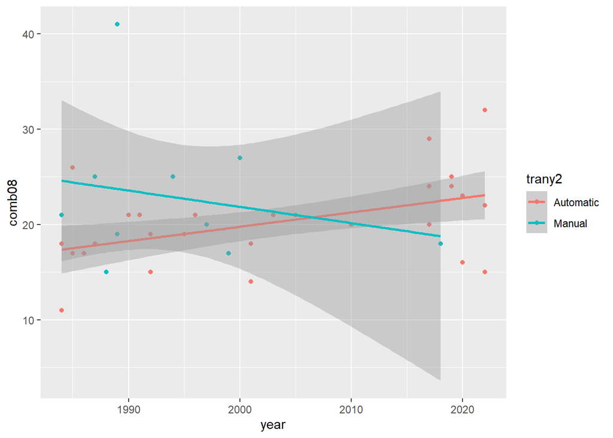

```r
g=gasoline_fuel[sample(1:nrow(gasoline_fuel), 40),]
library(ggplot2)
ggplot(data = g,
     aes(x = year, y = comb08,color = trany2, group = trany2)) +
     geom_point() + stat_smooth(method="lm")
```